# How can you build a dashboard to the field trials project you finished

Omer Perach

2020-06-19

Let’s take a data set from the `agridat` package:

The data is a field trial on 58 varieties of soybean, grown in four locations across two years in Australia. Now we look on the six first rows of the data:

```r
head(australia.soybean)
```

```
##   env   loc year gen yield height lodging  size protein    oil
## 1 L70 Lawes 1970 G01 2.387  1.445    4.25  8.45   36.70 20.895
## 2 L70 Lawes 1970 G02 2.282  1.450    4.25  9.95   37.55 20.740
## 3 L70 Lawes 1970 G03 2.567  1.460    3.75 10.85   37.80 21.295
## 4 L70 Lawes 1970 G04 2.877  1.260    3.50 10.05   38.45 21.990
## 5 L70 Lawes 1970 G05 2.392  1.335    3.50 11.00   37.50 22.130
## 6 L70 Lawes 1970 G06 2.408  1.360    4.00 11.75   38.25 21.160
```

We can also summarize the data set:

```r
summary(australia.soybean)
```

```
##       env              loc           year           gen          yield
##  B70    : 58   Brookstead:116   Min.   :1970   G01    :  8   Min.   :0.282
##  B71    : 58   Lawes     :116   1st Qu.:1970   G02    :  8   1st Qu.:1.515
##  L70    : 58   Nambour   :116   Median :1970   G03    :  8   Median :2.075
##  L71    : 58   RedlandBay:116   Mean   :1970   G04    :  8   Mean   :2.047
##  N70    : 58                    3rd Qu.:1971   G05    :  8   3rd Qu.:2.558
##  N71    : 58                    Max.   :1971   G06    :  8   Max.   :4.381
##  (Other):116                                   (Other):416
##      height          lodging          size           protein
##  Min.   :0.2500   Min.   :1.00   Min.   : 4.000   Min.   :33.20
##  1st Qu.:0.7075   1st Qu.:1.50   1st Qu.: 7.838   1st Qu.:38.14
##  Median :0.8875   Median :2.25   Median : 9.500   Median :40.25
##  Mean   :0.8831   Mean   :2.31   Mean   :11.138   Mean   :40.33
##  3rd Qu.:1.0450   3rd Qu.:3.00   3rd Qu.:14.050   3rd Qu.:42.20
##  Max.   :1.7300   Max.   :4.75   Max.   :23.600   Max.   :48.50
##
##       oil
##  Min.   :13.03
##  1st Qu.:17.97
##  Median :19.82
##  Mean   :19.92
##  3rd Qu.:22.09
##  Max.   :26.84
##
```

##### As we can see from the summary:

1. env variable is just a representation of place and year, first letter of location and the last two character of the year.
2. Location- because there are 58 varieties multipe by two years 1970 and 1971 we have 116 observations for each location.
3. Lodging - lodging is a level of the soy stem to bend, if the stem is bending too much, it can have effect on light penetration thus on yield.I cannot understand the Lodging units.
4. Size - seed size in milimieter ,w e can see very high ragnge from 4 to 23.
5. protein - percentage, probably from wet matter.
6. Oil - percentage probably from wet matter.
7. Gene:
   - Lines 1-40 Local selctions for Australia
   - Line 41 Avoyelles (CPI 15939) Tanzania
   - Line 42 Hernon 49 (CPI 15948) Tanzania
   - Line 43 Mamloxi (CPI 172) Nigeria
   - Line 44 Dorman USA
   - Line 45 Hampton USA
   - Line 46 Hill USA
   - Line 47 Jackson USA
   - Line 48 Leslie USA
   - Line 49 Semstar Australia
   - Line 50 Wills USA
   - Line 51 C26673 Morocco
   - Line 52 C26671 Morocco
   - Line 53 Bragg USA
   - Line 54 Delmar USA
   - Line 55 Lee USA
   - Line 56 Hood USA
   - Line 57 Ogden USA
   - Line 58 Wayne USA

Let’s inquire each continuous variable individually for 1970 per strain:

```r
df_1970<-australia.soybean%>%filter(year==1970)
label<-seq(1,58)
label
```

```
##  [1]  1  2  3  4  5  6  7  8  9 10 11 12 13 14 15 16 17 18 19 20 21 22 23 24 25
## [26] 26 27 28 29 30 31 32 33 34 35 36 37 38 39 40 41 42 43 44 45 46 47 48 49 50
## [51] 51 52 53 54 55 56 57 58
```

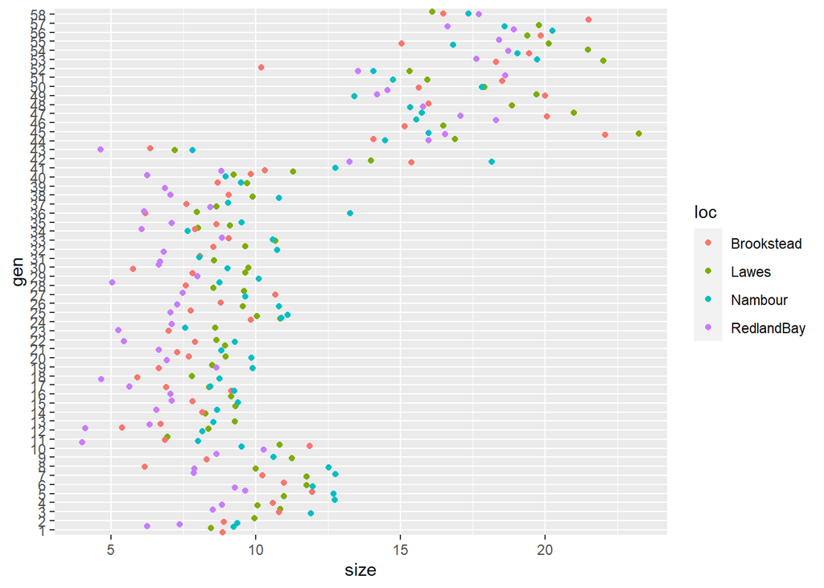

```r
df_1970%>%ggplot(aes(gen,size))+geom_jitter(aes(color=loc))+coord_flip()+scale_x_discrete(label=label)
```

Now we will look on the protein percentage

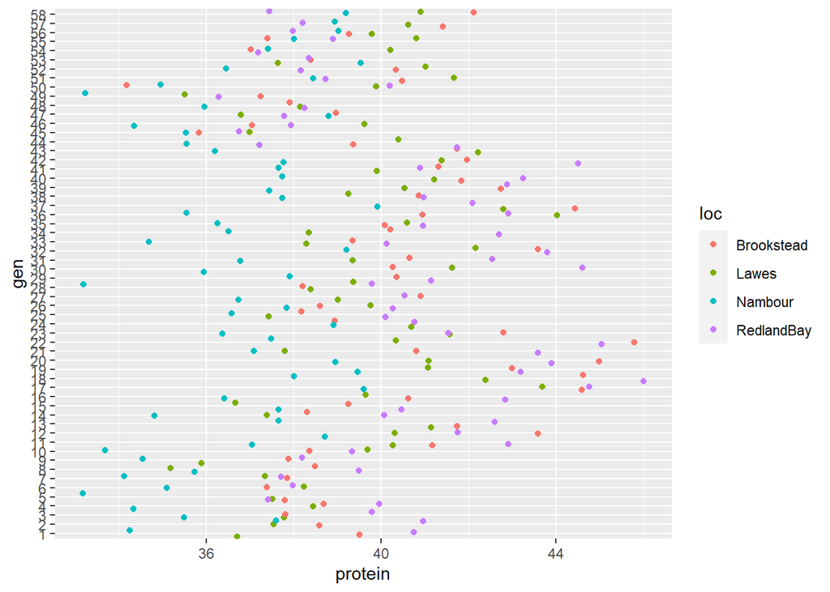

```r
df_1970%>%ggplot(aes(gen,protein))+geom_jitter(aes(color=loc))+coord_flip()+scale_x_discrete(label=label)
```

##### Link to the dashboard I built for this data (Dashboard) [ https://omerperach.shinyapps.io/agridata/]